# Reproducible research with workflowr

workflowr version 1.6.2

John Blischak and Matthew Stephens

2020-08-16

## Introduction

The workflowr R package makes it easier for you to organize, reproduce, and share your data analyses. This short tutorial will introduce you to the workflowr framework. You will create a workflowr project that implements a small data analysis in R, and by the end you will have a working website that you can use to share your work. Please follow the setup instructions in the next section prior to the workshop.

Workflowr combines literate programming with [R Markdown](http://rmarkdown.rstudio.com/) and version control with [Git](https://git-scm.com/) to generate a website containing time-stamped, versioned, and documented results. By the end of this tutorial, you will have a website hosted on [GitHub Pages](https://pages.github.com/) that contains the results of a reproducible statistical analysis.

## Setup

1. Install [R](https://cran.r-project.org)
2. Install [RStudio](https://www.rstudio.com/products/rstudio/download/)
3. Install workflowr from [CRAN](https://cran.r-project.org/package=workflowr):

   ```r
   install.packages("workflowr")
   ```

4. Create an account on [GitHub](https://github.com)

To minimize the possibility of any potential issues with your computational setup, you are encouraged to update your version of RStudio (`Help` -> `Check for Updates`) and update your R packages:

```r
update.packages()
```

If you do encounter any issues during the tutorial, consult the Troubleshooting section for solutions to the most common problems.

## Organize your research

To help you stay organized, workflowr creates a project directory with the necessary configuration files as well as subdirectories for saving data and other project files. This tutorial uses the [RStudio project template](https://rstudio.github.io/rstudio-extensions/rstudio_project_templates.html) for workflowr, but note that the same can be achieved via the function `wflow_start()`.

To start your workflowr project, follow these steps:

1. Open RStudio.
2. In the R console, run `wflow_git_config()` to register your name and email with Git. This only has to be done once per computer. If you’ve used Git on this machine before, you can skip this step. For a better GitHub experience, use the same email you used to register your GitHub account.

   ```r
   library(workflowr)
   wflow_git_config(user.name = "First Last", user.email = "email@domain.com")
   ```

3. In the menu bar, choose `File` -> `New Project`.
4. Choose `New Directory` and then scroll down the list of project types to select `workflowr project`. If you don’t see the workflowr project template, go to Troubleshooting.

[figure not shown]

[figure not shown]

5. Type `myproject` (or a more inventive name if you prefer) as the directory name, choose where to save it on your computer, and choose `Create Project`.

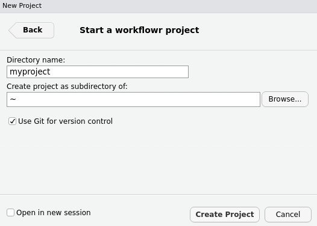

RStudio will create a workflowr project `myproject` and opened the project in RStudio. Under the hood, RStudio is running a workflowr command `wflow_start()` - so if you prefer to start a new project from the console instead of using the RStudio menus then you could use `wflow_start()`.

Take a look at the workflowr directory structure in the Files pane, which should be something like this:

```
    myproject/
    |-- .gitignore
    |-- .Rprofile
    |-- _workflowr.yml
    |-- analysis/
    |   |-- about.Rmd
    |   |-- index.Rmd
    |   |-- license.Rmd
    |   |-- _site.yml
    |-- code/
    |   |-- README.md
    |-- data/
    |   |-- README.md
    |-- docs/
    |-- myproject.Rproj
    |-- output/
    |   |-- README.md
    |-- README.md
```

The most important directory for you to pay attention to now is the `analysis/` directory. This is where you should store all your analyses as R Markdown (Rmd) files. Other directories created for your convenience include `data/` for storing data, and `code/` for storing long-running or supplemental code you don’t want to include in an Rmd file. Note that the `docs/` directory is where the website HTML files will be created and stored by workflowr, and should not be edited by the user.

## Build your website

The files and directories created by workflowr are already almost a website! The only thing missing are the crucial `html` files. Take a look in the `docs/` directory where the html files for your website need to be created… notice that it is sadly empty.

In workflowr the html files for your website are created in the `docs/` directory by knitting (or “building”) the `.Rmd` files in the `analysis/` directory. When you knit or build those files – either by using the knitr button, or by typing `wflow_build()` in the console – the resulting html files are saved in the docs directory.

The `docs/` directory is currently empty because we haven’t run any of the `.Rmd` files yet. So now let’s run these files. We will do it both ways, using both the knit button and using `wflow_build()`:

1. Open the file `analysis/index.Rmd` and knit it now. You can open it by using the files pane, or by typing `wflow_open("analysis/index.Rmd")` in the R console. You knit the file by pressing the knit button in RStudio.
2. There are also two other `.Rmd` files in the `analysis` directory. Build these by typing `wflow_build()` in the R console. This will build all the R Markdown files in `analysis/`, and save the resulting html files in `docs/`. (Note, it won’t re-build `index.Rmd` because you have not changed it since running it before, so it does not need to.[^1]

Ignore the warnings in the workflowr report for now; we will return to these later.

## Collect some data!

1. To get a quick sense of the data set, run the following in the R console.

   ```r
   data("ToothGrowth")
   head(ToothGrowth)
   ```

   ```
   ##    len supp dose
   ## 1  4.2   VC  0.5
   ## 2 11.5   VC  0.5
   ## 3  7.3   VC  0.5
   ## 4  5.8   VC  0.5
   ## 5  6.4   VC  0.5
   ## 6 10.0   VC  0.5
   ```

   ```r
   summary(ToothGrowth)
   ```

   ```
   ##       len        supp         dose
   ##  Min.   : 4.20   OJ:30   Min.   :0.500
   ##  1st Qu.:13.07   VC:30   1st Qu.:0.500
   ##  Median :19.25           Median :1.000
   ##  Mean   :18.81           Mean   :1.167
   ##  3rd Qu.:25.27           3rd Qu.:2.000
   ##  Max.   :33.90           Max.   :2.000
   ```

   ```r
   str(ToothGrowth)
   ```

   ```
   ## 'data.frame':    60 obs. of  3 variables:
   ##  $ len : num  4.2 11.5 7.3 5.8 6.4 10 11.2 11.2 5.2 7 ...
   ##  $ supp: Factor w/ 2 levels "OJ","VC": 2 2 2 2 2 2 2 2 2 2 ...
   ##  $ dose: num  0.5 0.5 0.5 0.5 0.5 0.5 0.5 0.5 0.5 0.5 ...
   ```

2. To mimic a real project that will have external data files, save the `ToothGrowth` data set to the `data/` subdirectory using `write.csv()`.

   ```r
   write.csv(ToothGrowth, file = "data/teeth.csv")
   ```

## Understanding paths

Look at that last line of code. Where will the file be saved on your computer? To understand this very important issue you need to understand the idea of “relative paths” and “working directory”.

Before explaining these ideas, let us consider a different way we could have saved the file. Suppose we had typed

```r
    write.csv(ToothGrowth, file = "C:/Users/GraceHopper/Documents/myproject/data/teeth.csv")
```

Then it is clear exactly where on the computer we want the file to be saved. Specifying the file location this very explicit way is called specifying the “full path” to the file. It is conceptually simple. But it is also a pain for many reasons – it is more typing, and (more importantly) if we move the project to a different computer it will likely no longer work because the paths will change!

Instead we typed

```r
    write.csv(ToothGrowth, file = "data/teeth.csv")
```

Specifying the file location this way is called specifying the “relative path” because it specifies the path to the file *relative to the current working directory*. This means the full path to the file will be obtained by appending the specified relative path to the (full) path of the current working directory. For example, if the current working directory is `C:/Users/GraceHopper/Documents/myproject/` then the file will be saved to `C:/Users/GraceHopper/Documents/myproject/data/teeth.csv`. If the current working directory is `C:/Users/Matt124/myproject` then the file will be saved to `C:/Users/Matt124/myproject/data/teeth.csv`.

So, what is your current working directory? When you start or open a workflowr project in RStudio (e.g. by clicking on `myproject.Rproj`) RStudio will set the working directory to the location of the workflowr project on your computer. So your current working directory should be the location you chose when you started your workflowr project. You can check this by typing `getwd()` in the R console.

Notice how, by using relative paths, the code used here works for you whatever operating system you are on and however your computer is set up! *You should always use relative paths where possible because it can help make your code easier for others to run and easier for you to run on different computers and different operating systems.*

## Create a new analysis

So, now we have some data, we are ready to perform a small analysis. To start a new analysis in RStudio, use the `wflow_open()` command.

1. In the R console, open a new R Markdown file by typing

   ```r
   wflow_open("analysis/teeth.Rmd")
   ```

   Notice that we again used a relative path! Relative paths are good for opening files as well as saving files. This command should create a new `.Rmd` file in the `analysis` subdirectory of your workflowr project, and open it for editing in RStudio. The file looks pretty much like other `.Rmd` files, but in the header note that workflowr provides its own custom output format, `workflowr::wflow_html`. The other minor difference is that `wflow_open()` adds the editor option `chunk_output_type: console`, which causes the code to be executed in the R console instead of within the document. If you prefer the results of the code chunks be embedded inside the document while you perform the analysis, you can delete those lines (note that this has no effect on the final results, only on the display within RStudio).
2. Copy the code chunk below and paste it at the bottom of the file `teeth.Rmd`. The code imports the data set from the file you previously created[^2]. Execute the code in the R console by clicking on the Run button or using the shortcut `Ctrl`/`CMD`+`Enter`.

   ````
   ```{r import-teeth}
   teeth <- read.csv("data/teeth.csv", row.names = 1)
   head(teeth)
   ```
   ````

   Note: if you copy and paste this chunk, make sure to remove any spaces before each of the backticks (`` ``` ``) so that they will be correctly recognized as indicating the beginning and end of a code chunk.
3. Next create some boxplots to explore the data. Copy the code chunk below and paste it at the bottom of the file `teeth.Rmd`. Execute the code to see create the plots.

   ````
   ```{r boxplots}
   boxplot(len ~ dose, data = teeth)
   boxplot(len ~ supp, data = teeth)
   boxplot(len ~ dose + supp, data = teeth)
   ```
   ````

4. To compare the tooth length of the guinea pigs given orange juice versus those given vitamin C, you could perform a [permutation-based statistical test](https://en.wikipedia.org/wiki/Resampling_%28statistics%29#Permutation_tests). This would involve comparing the observed difference in teeth length due to the supplement method to the observed differences calculated from random permutations of the data. The basic idea is that if the observed difference is an outlier compared to the differences generated after permuting the supplement method column, it is more likely to be a true signal not due to chance alone. We are not going to perform the full permutation test here, but we will just demonstrate the idea of a permutation. Copy the code chunk below, paste it at the bottom of of the file `teeth.Rmd`, and execute it. Try executing it several times – does it give you a different answer each time?

   ````
   ```{r permute}
   # Observed difference in teeth length due to supplement method
   mean(teeth$len[teeth$supp == "OJ"]) - mean(teeth$len[teeth$supp == "VC"])
   # Permute the observations
   supp_perm <- sample(teeth$supp)
   # Calculate mean difference in permuted data
   mean(teeth$len[supp_perm == "OJ"]) - mean(teeth$len[supp_perm == "VC"])
   ```
   ````

5. In the R console, run `wflow_build()`. Note the value of the observed difference in the permuted data.
6. In RStudio, click on the Knit button. Has the value of the observed difference in the permuted data changed? It should be identical. This is because workflowr always sets the same seed prior to running the analysis.[^3] To better understand this behavior as well as the other reproducibility safeguards and checks that workflowr performs for each analysis, click on the workflowr button at the top and select the “Checks” tab.

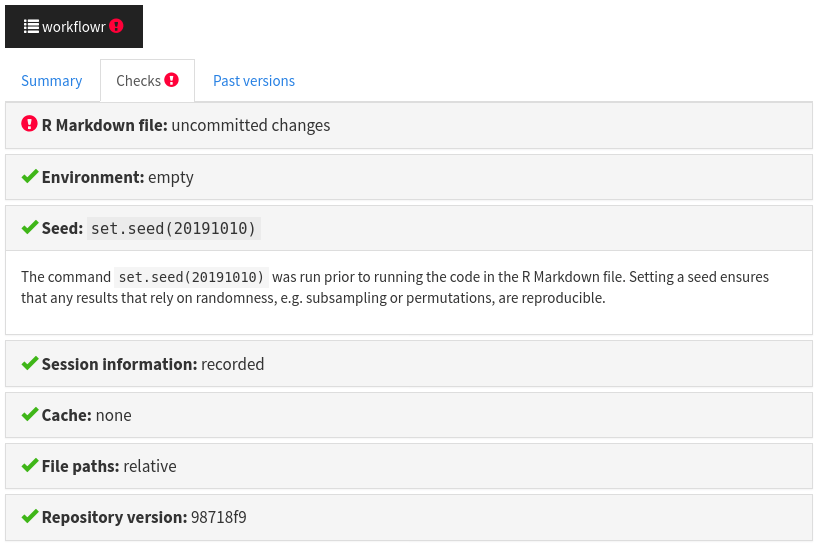

   You can see the value of the seed that was set using `set.seed()` before the code was executed.

## Publish your analysis!

You should also notice that workflowr is still giving you a warning: it says you have “uncommitted changes” in your .Rmd file. The term “commit” is a term from version control: it basically means to save a snapshot of the current version of a file so that you could return to it later if you wanted (even if you changed or deleted the file in between).

So, workflowr is warning you that you haven’t saved a snapshot of your current analysis. If this analysis is something you are currently (somewhat) happy with then you should save a snapshot that will allow you to go back to it at any time in the future (even if you change the .Rmd file between now and then). In workflowr we use the term “publish” for this process: any analysis that you “publish” will be one that you can go back to in the future. You will see that it is pretty easy to publish an analysis so you should do it whenever you create a first working version, and whenever you make a change that you might want to keep. Don’t wait to think that it is your “final” version before publishing, or you will never publish!

1. Publish your analysis by typing:

   ```r
   wflow_publish("analysis/teeth.Rmd", message = "Analyze teeth growth")
   ```

   The function `wflow_publish()` performs three steps: 1) commits (snapshots) the .Rmd files, 2) rebuilds the Rmd files to create the html file and figures, and 3) commits the HTML and figure files. This guarantees that the results in each html file is always generated from an exact, known version of the Rmd file (you can see this version embedded in the workflowr report). An informative message will help you find a particular version later.
2. Open the workflowr report of `teeth.html` by clicking on the button at the top of the page. Navigate to the tab “Past versions”. Note that the record of all past versions will be saved here. Once the project has been added to GitHub (you will do this in the next section), the “Past versions” tab will include hyperlinks for convenient viewing of the past versions of the Rmd and HTML files.

[figure not shown]

## Checking your status

When you are working on several analyses over a period of time it can be difficult to keep track of which ones need attention, etc. You can use `wflow_status()` to check on all your files.

1. In the R console, run `wflow_status()`. This will show you the status of each of the Rmd files in your workflowr project. You should see that `teeth.rmd` has status “Published” because you just published it. But the other `.Rmd` files have status “Unpublished” because you haven’t published them yet. Also you will notice a comment that the file `data/teeth.csv` is “untracked”. This basically means that the data file has not had a snapshot kept, which is dangerous as our analyses obviously depend on the version of the data we use….
2. In the R console, run the command below to “publish” these other files [^4].

   ```r
   wflow_publish(c("analysis/*Rmd", "data/teeth.csv"), message = "Publish data and other files")
   ```

3. Navigate to check html files in the `docs` directory, you should find that they all have a green light and no warnings.
4. And run `wflow_status()` again to confirm all is OK. Everything is published!

## Share your results

So, now you have a website, with an analysis in it. But it is only on your computer, not the internet. To share your website with the world we will use the free service GitHub Pages.

1. In the R console, run the function `wflow_use_github()`. The only required argument is your GitHub username. The name of the repository will automatically be named the same as the directory containing the workflowr project, in this case “myproject”.

   ```r
   wflow_use_github("your-github-username")
   ```

   When the function asks if you would like it to create the repository on GitHub for you, enter `1`. This should open your web browser so that you can authenticate with GitHub and then give permission for workflowr to create the repository on your behalf. Additionally, this function connects to your local repository with the remote GitHub repository and inserts a link to the GitHub repository into the navigation bar. If this fails to create a GitHub repository, go to Troubleshooting.
2. To update your workflowr website to use GitHub links to past versions of the files (as well as update the navigation bar to include the GitHub link), republish the files. (You would not have to do this in future)

   ```r
   wflow_publish(republish = TRUE)
   ```

3. To send your project to GitHub, run `wflow_git_push()`. This will prompt you for your GitHub username and password. If this fails, go to Troubleshooting.

   ```r
   wflow_git_push()
   ```

4. On GitHub, navigate to the Settings tab of your GitHub repository[^5]. Scroll down to the section “GitHub Pages”. For Source choose “master branch /docs folder”. After it updates, scroll back down and click on the URL. If the URL doesn’t display your website, go to Troubleshooting.

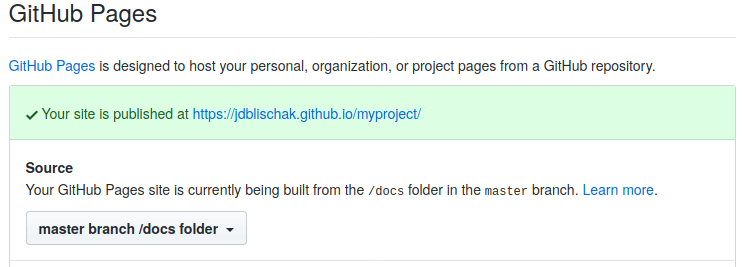

## Index your new analysis

Unfortunately your home page is not very inspiring. Also there is not an easy want to find that nice analysis you did! A great way to keep track of analyses and make them easy to find is to keep an index on your website homepage. The homepage is created by `analysis/index.Rmd`, so we are now going to edit this file to add a link to our new analysis.

1. Open the file `analysis/index.Rmd`. You can open it from the Files pane or run `wflow_open("analysis/index.Rmd")`.
2. Copy the line below and paste it at the bottom of the file `analysis/index.Rmd`. This text uses “markdown” syntax to create a hyperlink to the tooth analysis. The text between the square brackets is displayed on the webpage, and the text in parentheses is the relative path to the teeth webpage. Note that you don’t need to include the subdirectory `docs/` because `index.html` and `teeth.html` are both already in `docs/`. (In an html file relative paths are specified relative to the current page which in this case will be `index.html`.) Also note that you need to use the file extension `.html` since that is the file that needs to be opened by the web browser.

   ```
   * [Teeth growth analysis](teeth.html)
   ```

3. Maybe you would like to write a short introductory message in your index file e.g. “Welcome to my first workflowr website”!
4. You might also want to add a bit more details on what the tooth growth analysis did – a little detail in your index can be really helpful when it starts getting bigger…
5. Run `wflow_build()` and then confirm that clicking on the link “Teeth growth” takes you to your teeth analysis page.
6. Run `wflow_publish()` to publish this new index file.
7. Run `wflow-status()` to check everything is OK.
8. Run `wflow_git_push()` to push the changes to GitHub.
9. Now go to your GitHub page again, and check out your website! (It can take a couple of minutes to refresh after pushing, so you may need to be patient). Navigate to the tooth analysis. Click on the links in the “Past versions” tab to see the past results. Click on the HTML hyperlink to view the past version of the HTML file. Click on the Rmd hyperlink to view the past version of the Rmd file on GitHub. Enjoy!

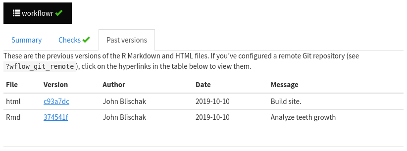

## Conclusion

You have successfully created and shared a reproducible research website. The key commands are a pretty short list: `wflow_build()`, `wflow_publish()`, `wflow_status()`, and `wflow_git_push()`. Using the same workflowr commands, you can do the same for one of your own research projects and share it with collaborators and colleagues.

To learn more about workflowr, you can read the following vignettes:

- Customize your research website
- Migrating an existing project to use workflowr
- How the workflowr package works
- Frequently asked questions
- Hosting workflowr websites using GitLab
- Sharing common code across analyses
- Alternative strategies for deploying workflowr websites

## Troubleshooting

### I don’t see the workflowr project as an available RStudio Project Type.

If you just installed workflowr, close and re-open RStudio. Also, make sure you scroll down to the bottom of the list.

### The GitHub repository wasn’t created automatically by `wflow_use_github()`.

If `wflow_use_github()` failed unexpectedly when creating the GitHub repository, or if you declined by entering `n`, you can manually created the repository on GitHub. After logging in to GitHub, click on the “+” in the top right of the page. Choose “New repository”. For the repository name, type `myproject`. Do not change any of the other settings. Click on the green button “Create repository”. Once that is completed, you can return to the next step in the tutorial.

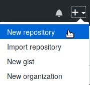

### I wasn’t able to push to GitHub with `wflow_git_push()`.

Unfortunately this function has a high failure rate because it relies on the correct configuration of various system software dependencies. If this fails, you can push to Git using another technique, but this will require that you have previously installed Git on your computer. For example, you can use the RStudio Git pane (click on the green arrow that says “Push”). Alternatively, you can directly use Git by running `git push` in the terminal.

### My website isn’t displaying after I activated GitHub Pages.

It is not uncommon for there to be a short delay before your website is available. One trick to try is to specify the exact page that you want at the end of the URL, e.g. add `/index.html` to the end of the URL.